#### Avaliação de Análise de Dados - Big Data 2017/2018 - Prof. Leandro Escobar

#### Realizado por Frederico Luz Braga

# Leia atentamente e construa o que se pede.

A base de dados disponibilizadas foi coletada pela embaixada americana em Hong Kong e possui dados relativas a data, horário, condições meteorológicas e concentração de partículas PM2.5 (conhecidas por causarem riscos à saúde) na atmosfera.

Artigo sobre a influencia de partículas suspensas (PM2.5) sobre a saúde respiratória: https://www.ncbi.nlm.nih.gov/pmc/articles/PMC4740125/ Paper que utiliza os dados: Liang, X., Zou, T., Guo, B., Li, S., Zhang, H., Zhang, S., Huang, H. and Chen, S. X. (2015). Assessing Beijing's PM2.5 pollution: severity, weather impact, APEC and winter heating. Proceedings of the Royal Society A, 471, 20150257. Link para a descrição da base de dados http://archive.ics.uci.edu/ml/datasets/Beijing+PM2.5+Data Link para download da base: http://archive.ics.uci.edu/ml/machine-learning-databases/00381/

Seu objetivo é estudar, demonstrar as características do fenômeno e desenvolver um modelo preditivo que permita antecipar a quantidade de PM2.5 suspensa no ar, propondo um sistema de alertas para a região. Lembre-se de que há duas dimensões no seu trabalho: Demostrar o fenômeno e suas características mediante análise de dados; Elaborar um modelo preditivo quantitativo e linear (Regressão Linear) para antecipar situações de risco à saúde.

1 Apresente os dados, concentração e dispersão quanto á chuva e nevascas na região de Hong Kong

2 Apresente os dados, concentração e dispersão quanto ao volume de partículas suspensas (PM2.5) na atmosfera de Hong Kong.

3 Demostre se há diferenças significativas na concentração de PM2.5 quanto à estação do ano, temperatura, chuva, neve e períodos (manhã, tarde e noite).

4 Desenvolva um modelo de regressão que permita prever a concentração de partículas PM2.5 suspensas na atmosfera de Hong Kong. Estabeleça um limiar que possa se utilizado como alerta, antecipando riscos à saúde, o que pode ser utilizado pelas autoridades sanitárias da região. Se necessário, pesquise quais são as indicações da OMS para tais fenômenos.

```python
#libs necessários
import pandas as pd
import numpy as np
import sklearn
import matplotlib.pyplot as plt
import time
import datetime
```

```python
#Buscar data de arquivo
data = train = pd.read_csv('PRSA_data_2010.1.1-2014.12.31.csv')
data.head()
```

|  | No | year | month | day | hour | pm2.5 | DEWP | TEMP | PRES | cbwd | Iws | Is | Ir |
| --- | --- | --- | --- | --- | --- | --- | --- | --- | --- | --- | --- | --- | --- |
| 0 | 1 | 2010 | 1 | 1 | 0 | NaN | -21 | -11.0 | 1021.0 | NW | 1.79 | 0 | 0 |
| 1 | 2 | 2010 | 1 | 1 | 1 | NaN | -21 | -12.0 | 1020.0 | NW | 4.92 | 0 | 0 |
| 2 | 3 | 2010 | 1 | 1 | 2 | NaN | -21 | -11.0 | 1019.0 | NW | 6.71 | 0 | 0 |
| 3 | 4 | 2010 | 1 | 1 | 3 | NaN | -21 | -14.0 | 1019.0 | NW | 9.84 | 0 | 0 |
| 4 | 5 | 2010 | 1 | 1 | 4 | NaN | -20 | -12.0 | 1018.0 | NW | 12.97 | 0 | 0 |

### As colunas da tabela possuem os seguintes significados:

- No: número da linha
- year: ano
- month: mês
- day: dia
- hour: hora
- pm2.5: concetração PM2.5 (ug/m^3)
- DEWP: Dew Point (â„ƒ)*
- TEMP: Temperatura(â„ƒ)
- PRES: Pressão (hPa)
- cbwd: Direção do vento
- Iws: Velocidade do vento acumulada(m/s)
- Is: Horas de nevasca acumuladas
- Ir: Horas de chuva acumuladas
- O DEW Point é conhecido como o 'Ponto de orvalho', que designa a temperatura a qual o vapor de água presente no ar ambiente passa ao estado líquido na forma de pequenas gotas por via da condensação, o chamado orvalho (Ref: https://pt.wikipedia.org/wiki/Ponto_de_orvalho)

```python
#métodos utils

def convertToTimestmap(d,m,y, h):

    date = str(d) + "/" + str(m) + "/" + str(y) + " " + str(h) + ":00"
    return time.mktime(datetime.datetime.strptime(date, "%d/%m/%Y %H:00" ).timetuple())
```

### 1) Apresente os dados, concentração e dispersão quanto á chuva e nevascas na região de Hong Kong:

```
month
1       15
2        7
3      291
4      547
5      861
6      829
7     1887
8      953
9     1859
10     578
11     708
12       7
Name: Ir, dtype: int64
```

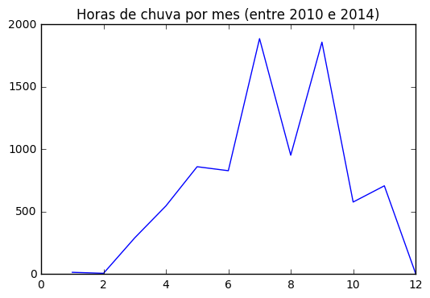

```python
#mostrar acumulado de horas de chuva por mês

print data.groupby(['month'])['Ir'].sum()

plt.plot(data.groupby(['month'])['Ir'].sum())
plt.title('Horas de chuva por mes (entre 2010 e 2014)')
plt.show()
```

É possível observar que Julho (1887 horas) ,Agosto (953 horas) Setembro (1859 horas) são os meses com mais chuva. E que Dexembro ( 7 horas) , Janeiro (15 horas) e Fevereiro(7 horas) são os meses com menos horas de chuva.

```
month
1     760
2     840
3     331
4       0
5       0
6       0
7       0
8       0
9       0
10      0
11      4
12    376
Name: Is, dtype: int64
```

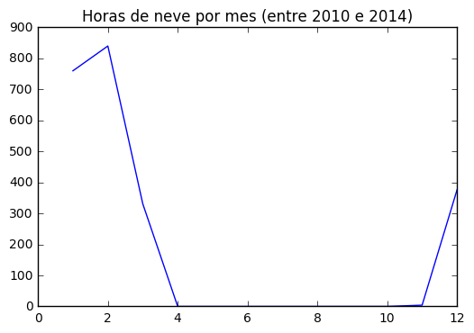

```python
#mostrar acumulado de horas de neve por mês

print data.groupby(['month'])['Is'].sum()

plt.plot(data.groupby(['month'])['Is'].sum())
plt.title('Horas de neve por mes (entre 2010 e 2014)')
plt.show()
```

É possível observar que neva em Hong Kong somente em Novembro (4 horas) , Dezembro (376 horas) , Janeiro (760 horas) , Fevereiro ( 840 horas) e Março (331 horas)

### 2) Apresente os dados, concentração e dispersão quanto ao volume de partículas suspensas (PM2.5) na atmosfera de Hong Kong.

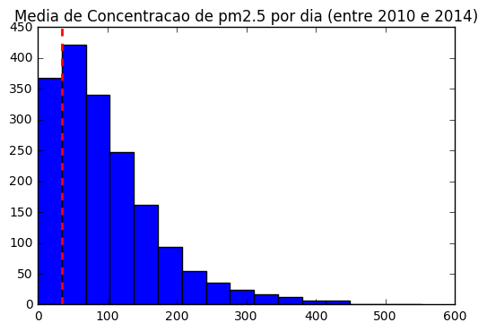

```
Média de PM2.5 por dia: 98.653437633
Desvio Padrao PM2.5 por dia: 77.5543511221
```

```python
#mostrar média de pm2.5 por dia

range = 16

df_avg_pm25_day =  data.groupby(['year','month', 'day'])['pm2.5'].mean()

n, bins, patches = plt.hist(df_avg_pm25_day.dropna(0), bins=range , range=(0,df_avg_pm25_day.max()) , rwidth='scalar')
plt.axvline(35, color='r', linestyle='dashed', linewidth=2)

plt.title('Media de Concentracao de pm2.5 por dia (entre 2010 e 2014)')
plt.show()

print 'Média de PM2.5 por dia:', df_avg_pm25_day.dropna().mean()
print 'Desvio Padrao PM2.5 por dia:' , df_avg_pm25_day.dropna().std()
```

De acordo com US Environmental Protection Agency’s (EPA), o limite aceitável de concentração de PM2.5 durante 24 horas é de 35 ug/m3 (representado com a linha vermelha).

A média por dia em Hong Kong é de 98 ug/m3. Três vezes mais que o limite.

### 3) Demostre se há diferenças significativas na concentração de PM2.5 quanto à estação do ano, temperatura, chuva, neve e períodos (manhã, tarde e noite).

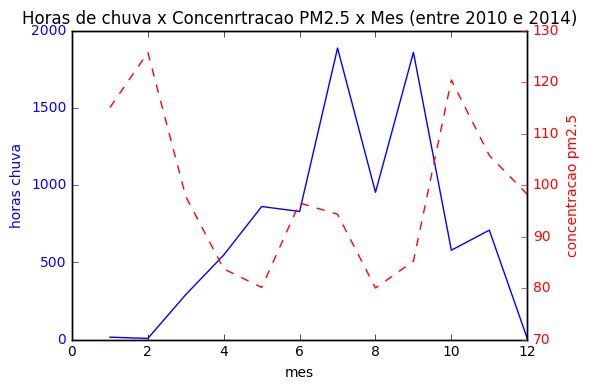

```python
# Análise de concentração de PM2.5 com a chuva a cada mês\

df_sum_chuva_month = data.groupby(['month'])['Ir'].sum()
df_avg_pm25_month  =  data.groupby(['month'])['pm2.5'].mean()

fig, ax1 = plt.subplots()

ax1.plot(df_sum_chuva_month, 'b-')
ax1.set_xlabel('mes')
# Make the y-axis label, ticks and tick labels match the line color.
ax1.set_ylabel('horas chuva', color='b')
ax1.tick_params('y', colors='b')

ax2 = ax1.twinx()
ax2.plot( df_avg_pm25_month, 'r--')
ax2.set_ylabel('concentracao pm2.5', color='r')
ax2.tick_params('y', colors='r')

plt.title('Horas de chuva x Concenrtracao PM2.5 x Mes (entre 2010 e 2014)')

fig.tight_layout()
plt.show()
```

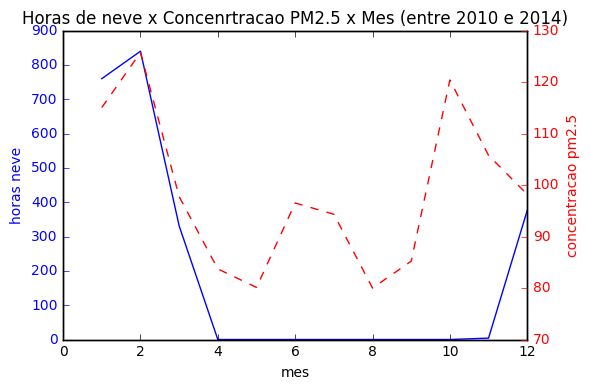

```python
# Análise de concentração de PM2.5 com a neve a cada mês\

df_sum_chuva_month = data.groupby(['month'])['Is'].sum()
df_avg_pm25_month  =  data.groupby(['month'])['pm2.5'].mean()

fig, ax1 = plt.subplots()

ax1.plot(df_sum_chuva_month, 'b-')
ax1.set_xlabel('mes')
# Make the y-axis label, ticks and tick labels match the line color.
ax1.set_ylabel('horas neve', color='b')
ax1.tick_params('y', colors='b')

ax2 = ax1.twinx()
ax2.plot( df_avg_pm25_month, 'r--')
ax2.set_ylabel('concentracao pm2.5', color='r')
ax2.tick_params('y', colors='r')

plt.title('Horas de neve x Concenrtracao PM2.5 x Mes (entre 2010 e 2014)')

fig.tight_layout()
plt.show()
```